# Interpreting breakpoint fits

## An idea

Look specifically at the predictions from the best-fitting breakpoint model. (This model could be: no breakpoints + no slope, no breakpoints + slope, n breakpoints + no slope, n breakpoints + slopes).

There’s some qualitative behaviors we can extract from the predictions (that come logically but less elegantly from the parameters, etc).

Two axes:

1. **Monotonic or squiggly:** Monotonic can encompass all linear (no-break) models, *and* any models with breakpoints that do not result in changes in direction.
2. **Net change or net 0:** The ratio of the end:beginning *prediction*.

The 2x2:

1. **Monotonic** and **net change**: This would be some kind of overall trend, either steady (probably would show as a 1-segment linear model), possibly accelerating or decelerating across the timeseries (would show as multiple segments with slopes), or even as a series of abrupt changes (would show as multiple segments with *no* slopes).
2. **Monotonic** and **no net change**: This can basically only be accomplished as a one-segment linear model with a slope very close to 0. (Theoretically you could have many verrrrry gently sloping segments, but I doubt we have the statistical power such that something like that would emerge as the best fit). I think this is either very stable or *so* variable that not even many breakpoints can adequately capture the variability.
3. **Turnpoints** and **net change**: The TS changes direction at least once, and ends up somewhere other than where it started. This *must* involve breakpoints. At the moment I think I have less confidence in such an outcome as evidence of systematic directional change - it seems potentially sensitive to, if we stopped surveying 5 years earlier, would we have a totally different trend?
4. **Turnpoints** and **no net change**: Qualitatively different from, monotonic and no net change….Again, I am not sure how confident I am in this as a signal of any kind of regulation/buffering. But maybe.

### Illustration via a few real datasets

```
## Loading in data version 2.18.0
```

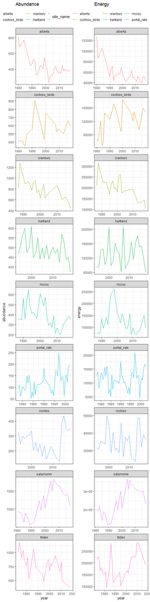

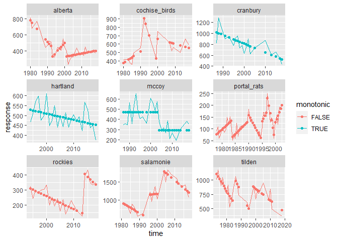

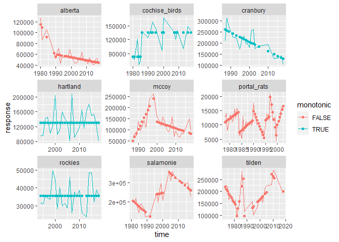

### Monotonic and net change

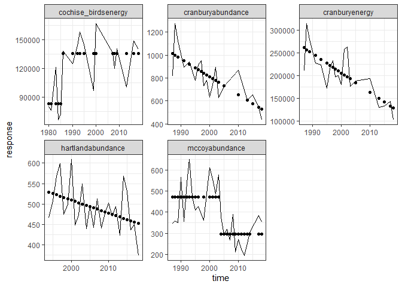

### Monotonic and no net change

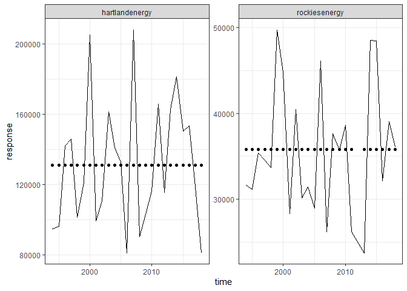

### Turnpoints and net change

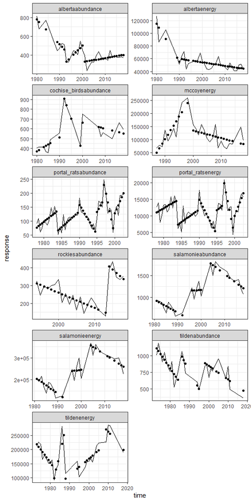